# Introduction to R and RStudio

## Why R?

From the outset, we need to recognize that there are lots of valuable standalone programs for evolutionary genetic analysis, many of which operate on Windows, Mac and Linux platforms and do so in a user-friendly fashion. However, there is one serious downside to exclusive dependence on such packages - many of them require specialized data formats, and outputs from one such program are often not readily input into another.

R, on the other hand, has a couple of advantages:

### It is a data oriented programming language,

so virtually any data can be input in some form or another. For example, one can directly read data from HapMap, SNPData, and other such data bases, and with some manipulation (a. k. a. munging) get them into a format that can be used for a wide variety of applications.

### R is vector-based

For those who remember the days of having to wrestle with subscript indices in languages like FORTRAN and BASIC, R is a delight. For example, suppose you wish to create a vector of integers from 1:100. It is as easy as

```r
x=c(1:100)
x
```

```
##   [1]   1   2   3   4   5   6   7   8   9  10  11  12  13  14  15  16  17
##  [18]  18  19  20  21  22  23  24  25  26  27  28  29  30  31  32  33  34
##  [35]  35  36  37  38  39  40  41  42  43  44  45  46  47  48  49  50  51
##  [52]  52  53  54  55  56  57  58  59  60  61  62  63  64  65  66  67  68
##  [69]  69  70  71  72  73  74  75  76  77  78  79  80  81  82  83  84  85
##  [86]  86  87  88  89  90  91  92  93  94  95  96  97  98  99 100
```

No need to set dimenstions or any of that stuff. And we can then do simple manipulations on those objects, such as

```r
x*2
```

```
##   [1]   2   4   6   8  10  12  14  16  18  20  22  24  26  28  30  32  34
##  [18]  36  38  40  42  44  46  48  50  52  54  56  58  60  62  64  66  68
##  [35]  70  72  74  76  78  80  82  84  86  88  90  92  94  96  98 100 102
##  [52] 104 106 108 110 112 114 116 118 120 122 124 126 128 130 132 134 136
##  [69] 138 140 142 144 146 148 150 152 154 156 158 160 162 164 166 168 170
##  [86] 172 174 176 178 180 182 184 186 188 190 192 194 196 198 200
```

And every element is multiplied by 2.

### And we can do plots.

Working with our same vector, we can easily get a simple working plot by

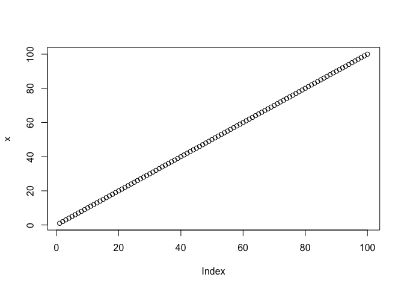

```r
plot(x)
```

### R is imminently extensible

with both built-in functions that carry out complex tasks based on simple commands, as well as add on packages that provide additional capabilities for specialized tasks. For example, suppose we want to generate a bunch of random binomial variants, akin to doing 100 experiments of flipping a coin 100 times qne plotting how many heads we get. We can write

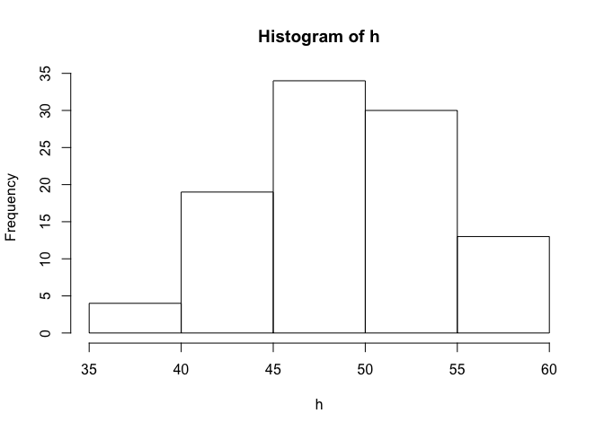

```r
h <-rbinom(100,100,.5)
hist(h)
```

### And then there are packages.

R is open source, so there are legions of skilled programmers specifically developing add-on packages that can be installed and provide additional functionality. We will use a lot of these packages, including

> - ape, pegas and adegent - provide essential functions for population genetic analysis and tree manipulation
> - phyclust - an independently developed package that has the interesting ability to run some otherwise command-line stand-alone programs (ms, seq-gen) directly within R
> - biomaRt - it takes a bit of learning, but with some effort one can use it to import an amazing variety of molecular sequence data directly from web sources.
> - rehh - Brings the world of Pardis Sabeti and extended haploytpe analaysis to R. Data munging is challenging, but once done, it is rewarding.

### A package example.

This one is purely fun, but it shows how web pages can be “scraped” to get useful data. [ALFRED](http://alfred.med.yale.edu/alfred/index.asp) is a database of human sequence variation - with a web based interface, you can generate a table showing allele frequencies for surveyed populations; those data can then be readily imported into R.

For example, the HYLA2 gene is of current interest, since it appears to have arisen from Neanderthal ancestors and been maintained by selection in asian population. We can get frequency data for it as follows

First, Use your browser to get to the data you want; when you have, copy the url onto the clipboard In this case, a search on the HYAL2 Gene turns up one SNP (rs11130248), Alfred ID number SI087775I, in the gene. We can pull down the data as follows:

```r
library(XML) # install the routines that allow web page scraping
hyal2.dat <-readHTMLTable("http://alfred.med.yale.edu/alfred/SiteTable1A_working.asp?siteuid=SI087775I",which=3)
```

which, roughly speaking, tells R to go to the URL and bring back the data in the third table on the page. We can inspect the first few lines of that file as follows:

```r
head(hyal2.dat)
```

```
##       V1                        V2           V3   V4   V5    V6    V7
## 1      A                         G         <NA> <NA> <NA>  <NA>  <NA>
## 2 Africa Bantu speakers(SA001818S) 16(6/5/2010)       N.A 0.880 0.130
## 3 Africa Bantu speakers(SA001819T) 24(6/5/2010)       N.A 0.750 0.250
## 4 Africa            San(SA001469U) 12(6/5/2010)       N.A 1.000     0
## 5 Africa          Biaka(SA002256P) 62(6/5/2010)       N.A 0.900 0.100
## 6 Africa          Mbuti(SA001466R) 30(6/5/2010)       N.A 0.930 0.070
```

And we see that we have the data broken out by continent, population, and allele frequency. We will return to this down the road, but suffice it to say that we can scrape a lot of data, and with some patience and ingenuity, get it into a form for doing all sorts of interesting things with it.

## What is RStudio?

R is a command line-driven program. That is, when a native R window, if you type a command, the comupter will attempt to execute it on the spot. Often times this is now what you wwant - rather , you would like to write a block of code, get it working , and then once it is use its output for further analysis. R studio makes this eassy.

### Installation is easy

Go to RStudio.org, look for the download program for your platform(Windows, Mac or whatver) and download it. Windows will probably have to be unzipped and executed; Mac will come as a DMG file that has to be installed. But be assured that in just a few minutes (I did it while wating to board a plane) you will have the system up and running.

When you open RStudio, you are presented with four pains.

1.The upper left is where you do most of the work, it is here you can type sets of commpands, run them and see what happens, 2. You can enter single commands in the lower left that will execute when you hit return, however the more valuable role of that panel is to display numerical results that arise for the command blocks you run in the upper left pane. 3. The upper right pane I think of a s a bookkepping area. It provides a list of all of the objects that are available in memory (and thus can be used in the currnet session). It gives the object name, as well as the nature of the object (vector, matrix, list, data frame, and many others.) 4. The lower right is where the graphs appear, and this is the fun stuff. R is exceptionally good at providing visualization of data in ways that can be readily interpreted; much of what we do will focus on interpretation of this output.